# Goals

### Question 4.4

Plot a bar chart to show the percentage of delayed flights over days in a week. Discuss your findings from the figure.

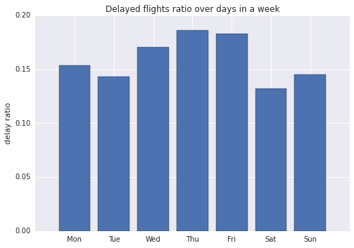

```python
delay=df[df.arrival_delay>15].groupBy(df.day_of_week).count().orderBy('day_of_week',ascending=1).collect()

total=df.groupBy(df.day_of_week).count().orderBy('day_of_week',ascending=1).collect()
L=[0 for k in range(len(total))]
for k,n in enumerate(total):
    for j in range(len(delay)):
        if delay[j][0]==n[0]: L[k]=(delay[j][1]/n[1])
dayss=[k[0] for k in total]
plt.bar(dayss,L,align='center')
days=['Mon','Tue','Wed','Thu','Fri','Sat','Sun']
plt.title('Delayed flights ratio over days in a week')
plt.xticks(dayss,days)
plt.ylabel('delay ratio')
```

**We notice in the figure above that the average delay is maximal in Wednesday,Thursday and Friday. Again, if we did the same analysis for a few years, it would help us have a reasonable conclusion.**

### Question 4.5

Plot a bar chart to show the percentage of delayed flights over months in a year. Discuss your findings from the figure.

```
(1, 12)
```

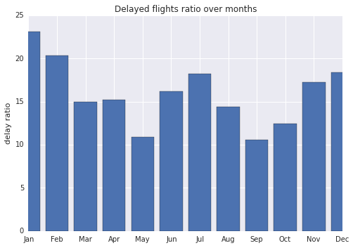

```python
delay=df[df.arrival_delay>15].groupBy(df.month).count().orderBy('month',ascending=1).collect()

total=df.groupBy(df.month).count().orderBy('month',ascending=1).collect()
L=[0 for k in range(len(total))]
for k,n in enumerate(total):
    for j in range(len(delay)):
        if delay[j][0]==n[0]: L[k]=(delay[j][1]/n[1])*100
monthss=[k[0] for k in total]
plt.bar(monthss,L,align='center')
plt.title('Delayed flights ratio over months')
plt.xticks(monthss,months)
plt.ylabel('delay ratio')
plt.xlim(1,12)
```

**At first, we might think that months with the higher number of flights will have the higher delay ratio, but, we can clearly see in the figure above that it's not the case. August, October and December have the highest number of flights, but not the highest delay ratio. February has the lowest number of flights, but has a very high delay ratio. So, to explain this figure and those results, we'll need aditionnal data (weather for example).**

We are ready now to draw some observations from our data, even if we have only looked at data coming from a year worth of flights:

- The probability for a flight to be delayed is low at the beginning or at the very end of a given months
- Flights on two first weekdays and on the weekend, are less likely to be delayed
- May and September are very good months for travelling, as the probability of delay is low (remember we're working on US data. Do you think this is also true in France?)

Putting things together, we can have a global picture of the whole year!

```python
from pyspark.sql.functions import col, expr, when
df_with_delay = df.withColumn('is_delay', when(df["arrival_delay"] >= 15, 1).otherwise(0))
statistic_day = df_with_delay.groupBy(['year','month', 'day_of_month', 'day_of_week'])\
    .agg((func.sum('is_delay')/func.count('*')).alias('delay_ratio'))

# assume that we do statistic on year 1994
statistic_day = statistic_day\
    .orderBy('year', 'month', 'day_of_month', 'day_of_week')
pdf = pd.DataFrame(data=statistic_day.collect())
```

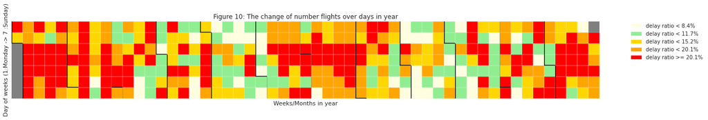

```python
fig = plt.figure(figsize=(20,10))
ax = fig.add_subplot(1,1,1)
plt.xlabel("Weeks/Months in year")
plt.ylabel("Day of weeks (1:Monday -> 7 :Sunday)")
plt.title('Figure 10: The change of number flights over days in year')

rec_size = 0.3
from matplotlib.patches import Rectangle
import datetime
num_days = len(pdf[0])
ax.patch.set_facecolor('gray')
ax.set_aspect('equal', 'box')
ax.xaxis.set_major_locator(plt.NullLocator())
ax.yaxis.set_major_locator(plt.NullLocator())

for i in range(0, num_days):
    # extract information from the result
    year = pdf[0][i]
    month = pdf[1][i]
    day_of_month = pdf[2][i]
    day_of_week = pdf[3][i]
    day_of_year= datetime.date(year=year, month=month, day=day_of_month).timetuple()
    week_of_year = datetime.date(year=year, month=month, day=day_of_month).isocalendar()[1]

    # dealing with the week of the previous year
    if week_of_year == 52 and month == 1:
        week_of_year = 0

    # the coordinate of a day in graph
    X = week_of_year*rec_size
    Y = day_of_week*rec_size

    # use different colors to show the delay ratio
    color = 'white'
    if pdf[4][i] <= 0.084:
        color = 'lightyellow'
    elif pdf[4][i] <= 0.117:
        color = 'lightgreen'
    elif pdf[4][i] <= 0.152:
        color = 'gold'
    elif pdf[4][i] <= 0.201:
        color = 'orange'
    else:
        color = 'red'
    rect = plt.Rectangle((X - rec_size/2.0, Y - rec_size/2.0), rec_size, rec_size,
                      alpha=1, facecolor=color, edgecolor='whitesmoke')

    ax.add_patch(rect)

    # drawing boders to separate months
    if day_of_month <= 7:
        rect2 = plt.Rectangle((X -rec_size/2.0, Y - rec_size/2.0), 0.01, rec_size,
                      alpha=1, facecolor='black')
        ax.add_patch(rect2)
    if day_of_month == 1:
        rect2 = plt.Rectangle((X - rec_size/2.0, Y - rec_size/2.0), rec_size, 0.01,
                      alpha=1, facecolor='black')
        ax.add_patch(rect2)
ax.autoscale_view()

patch1 = mpatches.Patch(color='lightyellow', label='delay ratio < 8.4%')
patch2 = mpatches.Patch(color='lightgreen', label='delay ratio < 11.7%')
patch3 = mpatches.Patch(color='gold', label='delay ratio < 15.2%')
patch4 = mpatches.Patch(color='orange', label='delay ratio < 20.1%')
patch5 = mpatches.Patch(color='red', label='delay ratio >= 20.1%')

plt.legend(handles=[patch1, patch2, patch3, patch4, patch5], bbox_to_anchor=(1.05, 1), loc=2, borderaxespad=0.)

plt.show()
```

### Question 4.6

What is the delay probability for the top 20 busiest airports? By drawing the flight volume of each airport and the associated delay probability in a single plot, we can observe the relationship between airports, number of flights and the delay.

HINT

Function `.isin()` helps checking whether a value in column belongs to a list.

SUGGESTION

You can try with different chart type to have a better visualization.

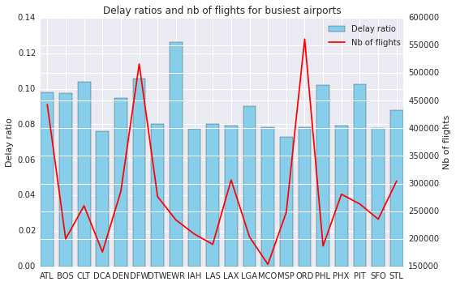

```
['ATL', 'BOS', 'CLT', 'DCA', 'DEN', 'DFW', 'DTW', 'EWR', 'IAH', 'LAS', 'LAX', 'LGA', 'MCO', 'MSP', 'ORD', 'PHL', 'PHX', 'PIT', 'SFO', 'STL']
```

```python
busiest=[]
L=busiest_airports.collect()
for i in range(20):
    busiest.append(L[i][0])
busiest.sort()
delays=df[df.src_airport.isin(busiest)][df.arrival_delay>15].groupBy('src_airport').count().selectExpr("src_airport as src_airport","count as count0")
dff=delays.join(busiest_airports, delays.src_airport==busiest_airports.airport, 'inner')
delay_pr_airports = dff.withColumn('Probability', dff.count0 / dff.total_flights).selectExpr("src_airport as airport","Probability as Probability").orderBy('airport',ascending=1)

M=delay_pr_airports.collect()
airports=[k[0] for k in M[:20]]
delay_p_air=[k[1] for k in M[:20]]
N=[]
for k in busiest:
    for j in L[:20]:
        if k==j[0]:
            N.append(j[1])
flighs_airp=N[:20]
y=delay_p_air
z=flighs_airp
x=range(20)

ax = plt.subplot(111)
b1=ax.bar(x, y,width=0.7,color='skyblue',label="Delay ratio",align='center')
# ax.bar(x, z,width=0.2,color='g',align='center')

plt.xticks(range(20),airports)
ax.legend([b1], ["Delay ratio"])

ax2=ax.twinx()
ax2.plot(x,z,'r',label="Nb of flights")

plt.legend(bbox_to_anchor=(0.785, 0.93), loc=2, borderaxespad=0.)
ax2.set_ylabel('Nb of flights')
ax.set_ylabel('Delay ratio')
plt.title("Delay ratios and nb of flights for busiest airports")
plt.show()
print(busiest)
```

The figure above shows that there are some airports with a very high number of flights, but a low delay ratio (like ORD). There are also some airports with a low number of flights but a high delay ratio (like EWR). DCA has low number of flights and a low delay ratio.  
Thus, there is no correlation between the delay ratio and the number of flights per airport.

### Question 4.7

What is the percentage of delayed flights which belong to one of the top 20 busiest carriers? Comment the figure!

SUGGESTION

You can try with different chart type to have a better visualization.

```
+-------+-------------------+
|carrier|         Percentage|
+-------+-------------------+
|     AA|0.16529669365077387|
|     AS|0.14394552032347308|
|     CO|0.18443632253513573|
|     DL| 0.1694415031685736|
|     HP|0.17262202630291648|
|     NW|0.12181284926615271|
|     TW|0.17115470265874014|
|     UA|0.15880704500978474|
|     US|0.17314251211671208|
|     WN|0.12075850774460319|
+-------+-------------------+
```

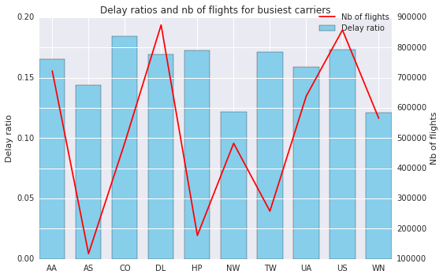

```python
bus_car=df.groupBy(df.carrier).count().orderBy('count',ascending=0).selectExpr("carrier as carrier0","count as count1")
L=bus_carr=bus_car.collect()
LL=[k[0] for k in bus_carr]
delays=df[df.carrier.isin(LL)][df.arrival_delay>15].groupBy('carrier').count().selectExpr("carrier as carrier","count as count0")
dff=delays.join(bus_car,delays.carrier==bus_car.carrier0, 'inner')
delay_pr_carrier = dff.withColumn('Percentage', dff.count0 / dff.count1).selectExpr("carrier as carrier","Percentage as Percentage").orderBy('carrier')
delay_pr_carrier.show()

M=delay_pr_carrier.collect()
carriers=[k[0] for k in M[:10]]
delay_p_car=[k[1] for k in M[:10]]
N=[]
LL.sort()
for k in LL:
    for j in L[:10]:
        if k==j[0]:
            N.append(j[1])
flighs_car=N[:10]
y=delay_p_car

z=flighs_car
x=range(10)

ax = plt.subplot(111)
b1=ax.bar(x, y,width=0.7,color='skyblue',label="Delay ratio",align="center")
# ax.bar(x, z,width=0.2,color='g',align='center')

plt.xticks(range(10),LL)
ax.legend([b1], ["Delay ratio"])

ax2=ax.twinx()
ax2.plot(x,z,'r',label="Nb of flights")

plt.legend(bbox_to_anchor=(0.785, 1.03), loc=2, borderaxespad=0.)
ax2.set_ylabel('Nb of flights')
ax.set_ylabel('Delay ratio')
plt.title("Delay ratios and nb of flights for busiest carriers")
```

## Addition (bonus) questions

### Additional data

In the HDFS file system you have used for running the Notebook, you will notice that there are several other years available (in addition to 1994).

There are some other datasets that related to this use case:

- Airport IATA Codes to City names and Coordinates mapping: http://stat-computing.org/dataexpo/2009/airports.csv
- Carrier codes to Full name mapping: http://stat-computing.org/dataexpo/2009/carriers.csv
- Information about individual planes: http://stat-computing.org/dataexpo/2009/plane-data.csv
- Weather information: http://www.wunderground.com/weather/api/. You can subscribe for free to the developers' API and obtain (at a limited rate) historical weather information in many different formats. Also, to get an idea of the kind of information is available, you can use this link: http://www.wunderground.com/history/

### Question 5.1

Which airports are present in the dataset only as destination airport? Which airport is present only as source airport in the dataset?

```python
src=df.select('src_airport').distinct().selectExpr("src_airport as Source_airports_only")

dest=df.select('dest_airport').distinct().selectExpr("dest_airport as Destination_airports_only")
# src.join(dest, src.src_airport==dest.dest_airport, 'outer').orderBy('src_airport','dest_airport').show()
# src.join(dest, src.src_airport==dest.dest_airport, 'outer').orderBy('dest_airport').show()
src.subtract(dest).show()
dest.subtract(src).show()
```

```
+--------------------+
|Source_airports_only|
+--------------------+
|                 SPN|
+--------------------+

+-------------------------+
|Destination_airports_only|
+-------------------------+
|                      BFI|
|                      GUM|
+-------------------------+
```

### Question 5.2

Which airports have biggest delay probability ? Which cities have largest delay duration in average ?

```python
print('Airports with the biggest delay probability:')
delay_pr_airports.orderBy('Probability',ascending=0).show()
```

```
Airports with the biggest delay probability:
+-------+-------------------+
|airport|        Probability|
+-------+-------------------+
|    EWR|0.12632964515729236|
|    DFW|0.10585588637872853|
|    CLT|0.10409222523410547|
|    PIT|0.10235453850512857|
|    PHL|0.10209366656500639|
|    ATL|0.09814161968429652|
|    BOS|0.09733795368960821|
|    DEN|0.09499310045319866|
|    LGA|0.09021351088207237|
|    STL|0.08806572736022916|
|    DTW|0.08024700295361094|
|    LAS|0.08010214827295703|
|    PHX|0.07944824636441403|
|    LAX|0.07911490505885078|
|    ORD|0.07830819950094485|
|    MCO|0.07823965651834504|
|    SFO|0.07801153398618979|
|    IAH|0.07762559266698947|
|    DCA|0.07594469522755018|
|    MSP|  0.073118799903218|
+-------+-------------------+
```

### Question 5.3

Is there any relationship between weather condition and the delay of flights in 1994 ?